# Introduction to Time Series

## What Is a Time Series Analysis

Time series analysis is a specific way of analyzing a sequence of data points collected over an interval of time.

The analysis can show how variables change over time. For example:

- Stock market
- Weather data
- Quarterly sales
- Audio processing
- Video processing

## Caracteristics of a Time Series

- Correlation introduced by the sampling of adjacent points
- Time domain analysis approach
- Fequency domain analysis approach

### Example of Real Time Series

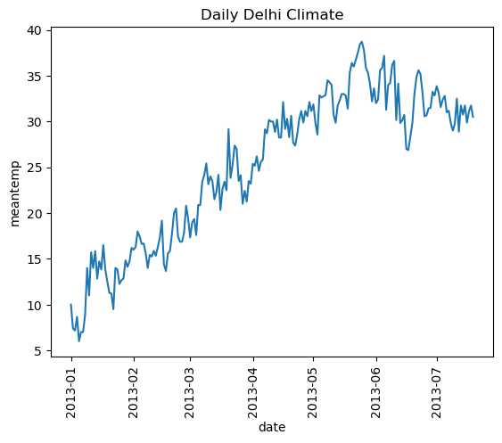

```python
ax.figure
```

## What Is a Time Series?

A time series can be defined as a collection of random variables indexed according to the order they are obtained in the time, for example $X_1, X_2, \cdots, X_n$.

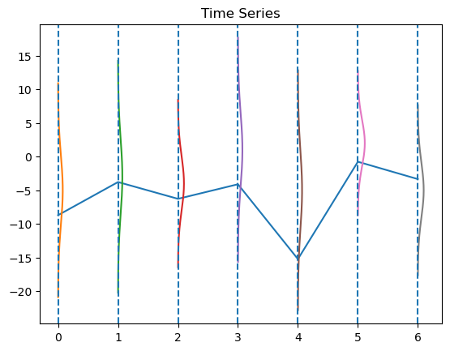

```python
ax.figure
```

## Time Series Statistical Models

The primary objective of a time series analysis is to develop mathematical models that provide plausible descriptions for sample data.

## White Noise

A simple kind of generated series might be a collection of uncorrelated random variables, $W_t$, with mean 0 and finite variance $\sigma^2_W$.The time series generated from uncorrelated variables is used as a model for noise, and it is called, *white noise*.

$$ W_t \sim_{i.i.d.} \mathcal{N}\left(0, \sigma^2_W\right) $$

### Example of White Noise

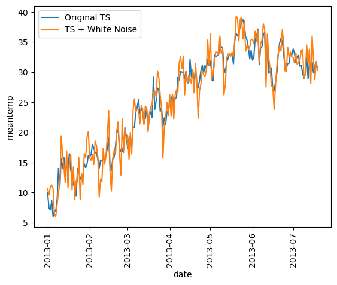

```python
ax.figure
```

## Moving Averages and Filtering

A second statistical model is moving averages. This is usually used for smothing the series.

$$ Y_t = \frac{X_1 + X_2 + \cdots + X_n}{n} $$

### Example of Moving Averages

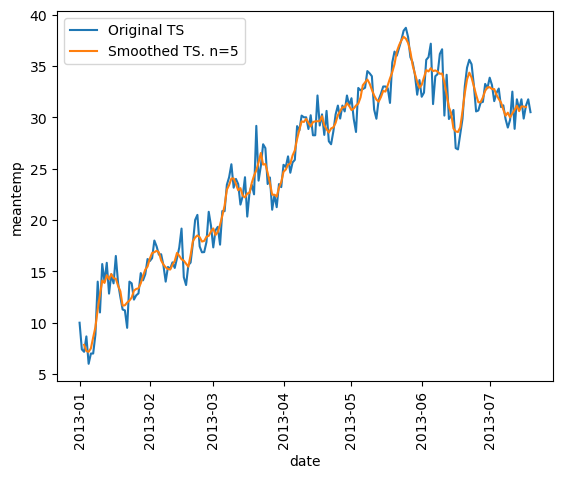

```python
ax.figure
```

## Autoregressions

The next statistical model is the autogressive one. If we want to express a future value in terms of past values this model is the option.

$$ X_t = \phi_1 X_{t-1} + \phi_2 X_{t-2} + \cdots + \phi_p X_{t-p} + W_t $$

### Example of Autoregressions

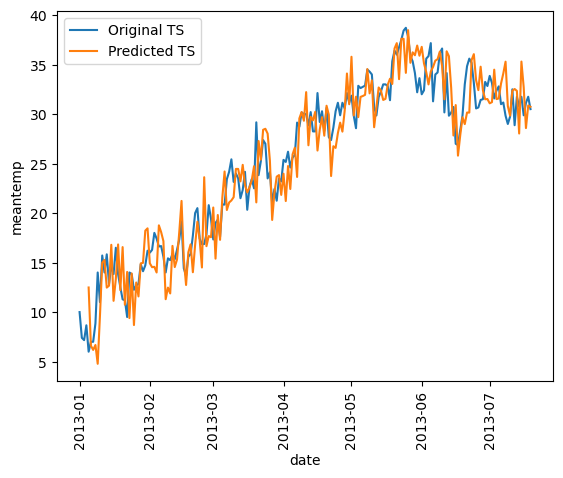

```python
ax.figure
```

## Random Walk With Drift

A moodel for analyzing trend is the random walk with drift model given by

$$ X_t = \delta + X_{t-1} + W_t $$

for $t=1,2,\cdots$, with initial condition $X_0=0$. The constant $\delta$ is called the drift, and when $\delta=0$ is called simply a random walk. This can be rewritten as:

$$ X_t = \delta t + \sum_{j=1}^{t} W_j $$

### Example of Random Walk With Drift

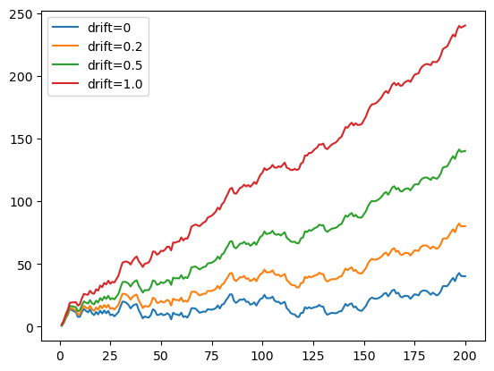

```python
ax.figure
```

## Signal in Noise

Many realistic models for generating time series assume an underlying signal with some consistent periodic variation, contaminated by adding a random noise. We can generate a periodic signal using

$$ X_t=Acos(2 \pi \omega t + \phi) + W_t $$

where $A$ is the amplitude, $\omega$ is the frequency, and $\phi$ is the phase.

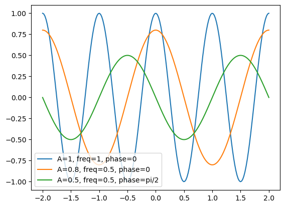

```python
ax.figure
```